# Data Cleansing

Wednesday, February 11, 2015

## 데이터를 구했을 때 생길 수 있는 상황

- 원하는 형태의 데이터가 아니다
- 값이 없는 것도 있다
- 데이터의 내용을 수정하고 싶다
- 자료를 합치고 싶다
- 중복된 내용을 제거하고 싶다
- 기타 등등..

## 데이터 전처리

- 데이터를 특정 분석 목적에 맞게 분석 가능한 상태로 만드는 것
- **단정한 데이터** 를 만들자!!

## Tidy Data??

### wide format

```
##    A1 A2 A3
## B1 10  7 12
## B2  9 11  6
```

### long format

```
##   Aval Bval value
## 1   A1   B1    10
## 2   A1   B2     9
## 3   A2   B1     7
## 4   A2   B2    11
## 5   A3   B1    12
## 6   A3   B2     6
```

## Tidy Data

- 각 변수는 각각의 열에 속한다
- 각 관측치는 행을 구성한다
- 각 테이블은 단 하나의 관측기준에 따라 조직된 데이터를 저장한다

## Tidy Data를 사용해야하는 이유??

- 다양한 데이터 포맷으로 쉽게 바꿀 수 있다
- 모델링과 시각화가 편하다

## 서울시 중구 가로등 현황 자료

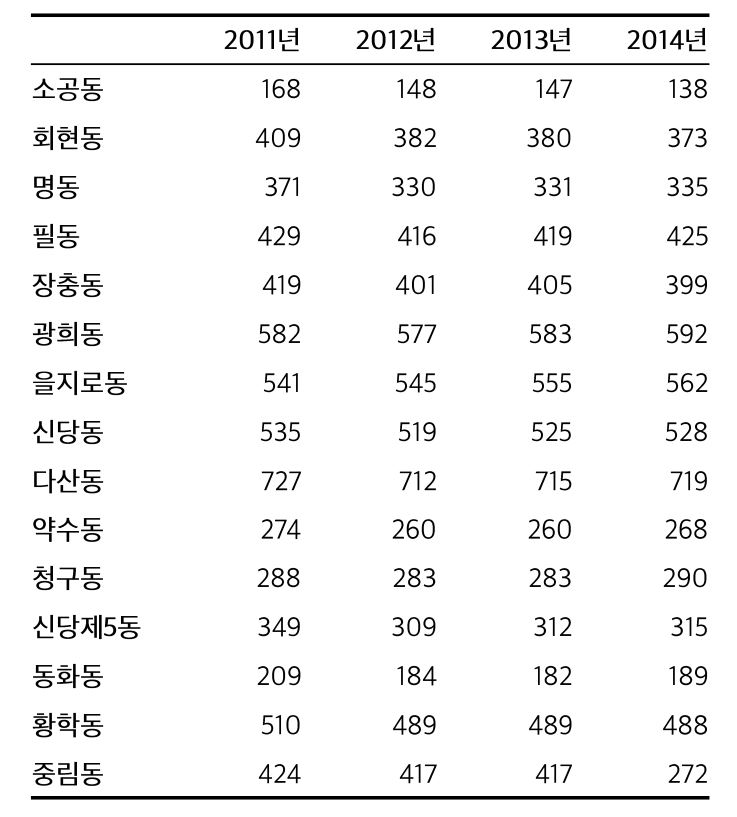

- 연도별로 세분화한 열을 제공하기  
  때문에 **tidy data가 아니다**
- row수를 줄여 한정된 페이지 공간에서 자료를 보여줄 수 있다

## 서울시 중구 가로등 현황 자료

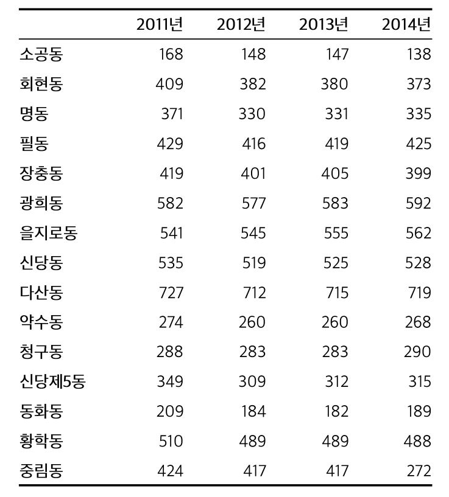

**Tidy data로 만들고 데이터를 다뤄보자**

## 자료 가져오기 + 패키지 설치하기

- 자료 불러오기

```r
streetlamp <-
read.csv(
"https://raw.githubusercontent.com/lumiamitie/lumiamitie.github.io/master/data/streetlamp.csv",
header = T,
fileEncoding = "UTF-8")
# 안되면 lumiamitie.github.io/data/streetlamp.csv 에서 파일 다운로드
# 맥, 리눅스 유저분들은 fileEncoding 옵션 없어도 될거에요
```

- **reshape2**, **dplyr** 패키지 설치

```r
# install.packages(reshape2)

library(reshape2)

# install.packages(dplyr)

library(dplyr)
```

## 패키지 설명

### reshape2

- **wide format <-> long format**
- melt : wide format -> long format
- cast : long format -> wide format

### dplyr

- **A Grammar of Data Manipulation**
- select
- filter
- mutate
- summarise
- arrange

## reshape2::melt

- 패키지이름::함수명 입니다
- melt는 피벗테이블 처럼 생긴 자료를 *id*, *variable*, *value* 형태로 반환해준다
- *melt(데이터, value.name = "value변수이름")*

```r
tidy_streetlamp <- melt(streetlamp, value.name = "count")
```

```r
head(tidy_streetlamp)
```

```
##        X variable count
## 1 소공동  X2011년   168
## 2 회현동  X2011년   409
## 3   명동  X2011년   371
## 4   필동  X2011년   429
## 5 장충동  X2011년   419
## 6 광희동  X2011년   582
```

## base::names

- names()는 각 열의 이름들을 반환해준다
- *names(데이터프레임) = c(열 이름 목록)* 을 통해 원하는 이름으로 변경할 수 있다

```r
names(tidy_streetlamp) = c("location", "year", "count")

head(tidy_streetlamp)
```

```
##   location    year count
## 1   소공동 X2011년   168
## 2   회현동 X2011년   409
## 3     명동 X2011년   371
## 4     필동 X2011년   429
## 5   장충동 X2011년   419
## 6   광희동 X2011년   582
```

## base::gsub

- gsub()은 특정 문자열/패턴을 찾아서 원하는 문자열로 변환시킨다
- 정규표현식을 사용할 수 있으니 궁금하면 **?regex** 로 검색해봐요
- *gsub("찾을단어", "바꿀단어", "데이터")*

```r
tidy_streetlamp$year <- gsub("X|년", "", tidy_streetlamp$year)

head(tidy_streetlamp)
```

```
##   location year count
## 1   소공동 2011   168
## 2   회현동 2011   409
## 3     명동 2011   371
## 4     필동 2011   429
## 5   장충동 2011   419
## 6   광희동 2011   582
```

## dplyr::mutate

- mutate() 함수는 열을 추가할 수 있다
- 새로 생성한 열도 같은 함수 내에서 바로 사용할 수 있다
- *mutate(데이터, 추가할 열 = 연산내용)*

```r
dplyr_streetlamp <- melt(streetlamp, value.name = "count")
```

```r
dplyr_streetlamp <- mutate(dplyr_streetlamp, year = gsub("X|년","",variable))
head(dplyr_streetlamp)
```

```
##        X variable count year
## 1 소공동  X2011년   168 2011
## 2 회현동  X2011년   409 2011
## 3   명동  X2011년   371 2011
## 4   필동  X2011년   429 2011
## 5 장충동  X2011년   419 2011
## 6 광희동  X2011년   582 2011
```

## dplyr::select

- select()는 특정 열을 추출한다
- *select(데이터, 추출할열이름, -제외할열이름)*

```r
dplyr_streetlamp <- select(dplyr_streetlamp, location = X, year, count)
head(dplyr_streetlamp)
```

```
##   location year count
## 1   소공동 2011   168
## 2   회현동 2011   409
## 3     명동 2011   371
## 4     필동 2011   429
## 5   장충동 2011   419
## 6   광희동 2011   582
```

## dplyr::filter

- filter()는 조건에 따라 행을 추출한다
- **&**(AND) 연산자를 이용하거나 **,** 로 구분하여 여러가지 조건을 줄 수 있다
- **|**(OR) 연산자를 이용해 조건을 줄 수 있다. (원화표시 또는 역슬래시 위에 있는 키)
- *filter(데이터, 조건)*

```r
filter(dplyr_streetlamp, year == 2011, count > 500)
```

```
##   location year count
## 1   광희동 2011   582
## 2 을지로동 2011   541
## 3   신당동 2011   535
## 4   다산동 2011   727
## 5   황학동 2011   510
```

## dplyr::group_by

- 열의 항목별로 그룹화된 결과를 얻을 수 있다
- *group_by(데이터, 변수명)*

```r
year_streetlamp <- group_by(dplyr_streetlamp, year)
head(year_streetlamp)
```

```
## Source: local data frame [6 x 3]
## Groups: year
##
##   location year count
## 1   소공동 2011   168
## 2   회현동 2011   409
## 3     명동 2011   371
## 4     필동 2011   429
## 5   장충동 2011   419
## 6   광희동 2011   582
```

## dplyr::summarise

- **summary function**을 적용하여 그룹별로 결과를 볼 수 있다
- summary function : 벡터를 입력받아서 단일 값을 반환하는 함수
- mean() : 평균, var() : 분산, n() : 개수 등

```r
summarise(year_streetlamp, mean(count))
```

```
## Source: local data frame [4 x 2]
##
##   year mean(count)
## 1 2011    415.6667
## 2 2012    398.1333
## 3 2013    400.2000
## 4 2014    392.8667
```

## group_by + mutate

- 그룹화 시킨 결과물에 mutate를 적용시키면 해당 값을 가지는 열을 새로 만든다

```r
mutate(year_streetlamp, mean(count))
```

```
## Source: local data frame [60 x 4]
## Groups: year
##
##    location year count mean(count)
## 1    소공동 2011   168    415.6667
## 2    회현동 2011   409    415.6667
## 3      명동 2011   371    415.6667
## 4      필동 2011   429    415.6667
## 5    장충동 2011   419    415.6667
## 6    광희동 2011   582    415.6667
## 7  을지로동 2011   541    415.6667
## 8    신당동 2011   535    415.6667
## 9    다산동 2011   727    415.6667
## 10   약수동 2011   274    415.6667
## ..      ...  ...   ...         ...
```

```r
mutate(year_streetlamp,
       mean = mean(count),
       diff = count - mean)
```

```
## Source: local data frame [60 x 5]
## Groups: year
##
##    location year count     mean        diff
## 1    소공동 2011   168 415.6667 -247.666667
## 2    회현동 2011   409 415.6667   -6.666667
## 3      명동 2011   371 415.6667  -44.666667
## 4      필동 2011   429 415.6667   13.333333
## 5    장충동 2011   419 415.6667    3.333333
## 6    광희동 2011   582 415.6667  166.333333
## 7  을지로동 2011   541 415.6667  125.333333
## 8    신당동 2011   535 415.6667  119.333333
## 9    다산동 2011   727 415.6667  311.333333
## 10   약수동 2011   274 415.6667 -141.666667
## ..      ...  ...   ...      ...         ...
```